# DeQoL LIFE - prelim descriptive results

Paul Schneider

2020-09-26

# PRELIMINARY NOTES

- Click on the ‘Code’ buttons on the right to view the source R code
- Descriptive results for eq5d index and dimensions by imd, age, sex, and year
- Sample: HSE 2003-2014
- Participants >= 16 (because eq5d missing for children)
- Participants >75 years were recoded to -> 75+ (because strata sizes too small)
- Analysis based on 1-year age band data
- 95% Confidence intervalls around mean estimates are bootstrapped with (only) 100 iterations
- **THERE SEEMS TO BE AN ISSUE WITH >1,500 PARTICPANTS HAVING AN EQ5D INDEX OF 0.919 BUT NO DIMENSION DATA (CODING ERROR?)**

# Setup and sample selection

```r
### load pkgs ----------------
library(ggplot2)
library(RColorBrewer)
library(reshape2)
library(cowplot)
library(dplyr)
library(knitr)

# # read raw data and extract + compute relevant vars
# # (only run once and then read processed data sets)
# source("./R/data_proc.R")
source("./R/utilities.R")

### load data ------

    # Load HSE data
    hse_combined <- read.csv("./data/HSE_combined/hse_combined.csv")

    # IMD factor labels
    hse_combined$imd <- factor(hse_combined$imd,
                               labels=c("Least deprived",
                                        "Less deprived",
                                        "Median deprived",
                                        "More deprived",
                                        "Most deprived"))
    # IMD color scheme
    imd_cols =  rev(brewer.pal(5,"RdYlGn"))
```

# Sample selection

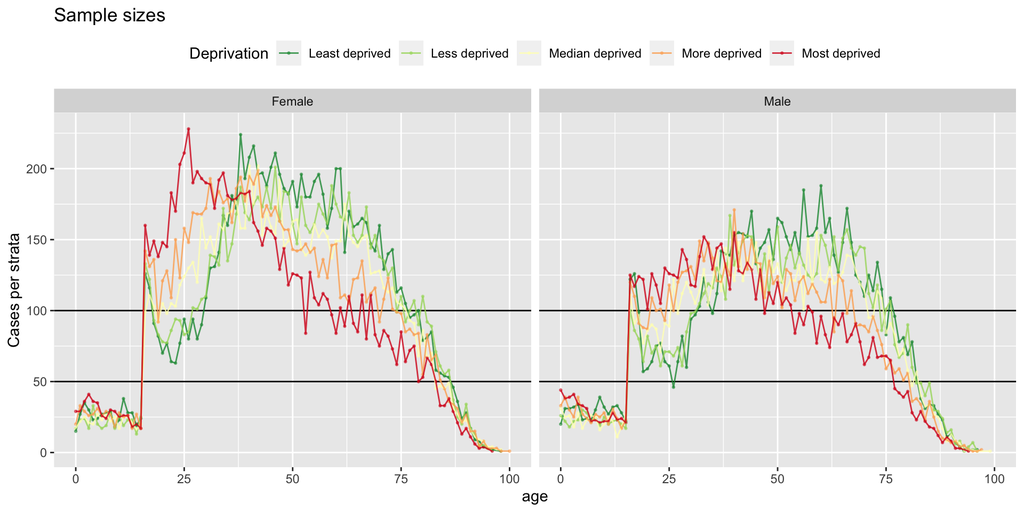

```r
    # remove years 2017 and 2018
    hse_combined = hse_combined[hse_combined$year <= 2014,]

    # remove NA's (for now)
    hse_combined = hse_combined[!is.na(hse_combined$eq5d),]

    # strata sample sizes
    n_size_strata <- aggregate(eq5d~imd+age+sex,hse_combined,function(x)sum(!is.na(x)))

    ggplot(n_size_strata,aes(x=age,y=eq5d,col=as.factor(imd))) +
        geom_hline(yintercept = 100) +
        geom_hline(yintercept = 50) +
        geom_point(size=0.5,alpha=0.5) +
        geom_line(size=0.5,alpha=0.8) +
        ggtitle("Sample sizes") +
        scale_color_manual(values =  imd_cols,name="Deprivation") +
        ylab("Cases per strata") +
        facet_wrap(~sex) +
        theme(legend.position = "top")
```

```r
    # remove age <16 bc no eq5d data (for now)
    hse_combined <- hse_combined[hse_combined$age > 15, ]

    # set max age 75
    hse_combined$age[hse_combined$age>75] <- 75
    # n total: rows, cols
    dim(hse_combined)
```

```
## [1] 86095    12
```

# mean eq5d over the lifespan by sex (years pooled)

Figure shows mean eq5d and 95% CI for the mean

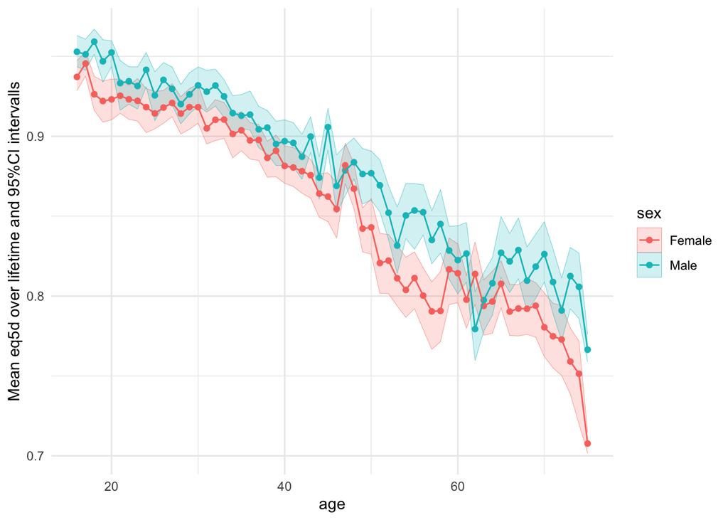

```r
    # mean eq5d over the lifespan by sex (years pooled) ------
    mean_lifespan_eq5d <- bootstrapci(hse_combined,"eq5d ~ age+sex",iterations = 100,print=F)

    # mean eq5d over lifetgime with 95%CI
    ggplot(mean_lifespan_eq5d, aes(x = age, y = eq5d, col = sex)) +
        geom_ribbon(aes(x=age,ymin=l95ci,ymax=u95ci,fill=sex),alpha=.2,size= 0.1) +
        geom_point() +
        geom_line() +
        ylab("Mean eq5d over lifetime and 95%CI intervalls") +
        theme_minimal()
```

# FIGURE 1: mean eq5d by age and imd and sex (years pooled)

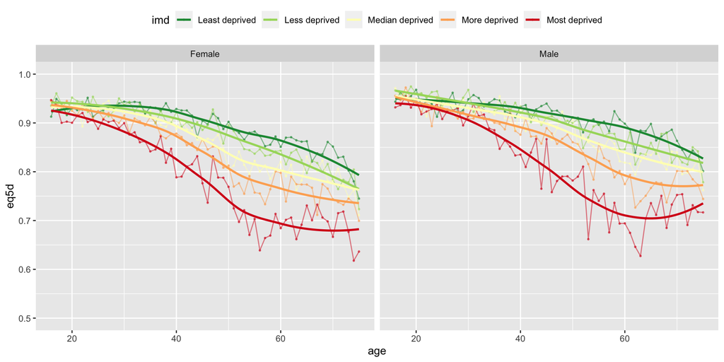

```r
# fig 1: mean eq5d by age and imd and sex -------
    # mean eq5d over the lifespan by sex and imd (years pooled)
    lifespan_imd_eq5d <- aggregate(eq5d ~ age + sex + imd, hse_combined, mean)
    # head(lifespan_imd_eq5d)

    # strata-size
    strata_sizes_eq5d <- aggregate( eq5d ~ age+sex+imd,hse_combined, length)
    names(strata_sizes_eq5d)[4] = "strata_n"
    # head(strata_sizes_eq5d)

    # ggplot(lifespan_imd_eq5d, aes(x = age, y = eq5d, col = imd)) +
    #     geom_point() +
    #     geom_line() +
    #     facet_wrap(~sex) +
    #     ylab("Mean eq5d score") +
    #     scale_color_manual(values = imd_cols ) +
    #     coord_cartesian(ylim=c(0.5,1))

    # smoothened
    ggplot(lifespan_imd_eq5d, aes(x = age, y = eq5d, col = imd)) +
        geom_point(size=0.5,alpha=.5) +
        geom_line(size=.5,alpha=.5) +
        geom_smooth(se=F) +
        facet_wrap(~sex) +
        scale_color_manual(values = imd_cols ) +
        coord_cartesian(ylim=c(0.5,1)) +
        theme(legend.position = "top")
```

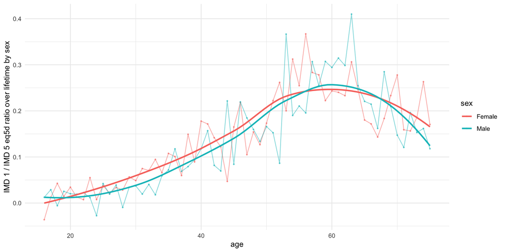

```r
# Figure 1 add on:
    # eq5d score inequality over lifetime by sex
    df_imd1 = aggregate(eq5d ~ sex+age+imd,hse_combined[as.numeric(hse_combined$imd) == 1,],mean)
    names(df_imd1)[4] = "eq5d_1"
    df_imd5 = aggregate(eq5d ~ sex+age+imd,hse_combined[as.numeric(hse_combined$imd) == 5,],mean)
    names(df_imd5)[4] = "eq5d_5"
    df_imd_r = merge(df_imd1,df_imd5,by=c("sex","age"))
    df_imd_r$ineq_ratio = df_imd_r$eq5d_1/df_imd_r$eq5d_5-1
    df_imd_r$ineq_diff = df_imd_r$eq5d_1-df_imd_r$eq5d_5

    ggplot(df_imd_r,aes(x=age,y=ineq_ratio,col=sex)) +
        geom_point(size=0.5,alpha=0.5) +
        geom_line(size=0.5,alpha=0.5) +
        geom_smooth(se=F) +
        ylab("IMD 1 / IMD 5 eq5d ratio over lifetime by sex") +
        theme_minimal()
```

```r
    # ggplot(df_imd_r,aes(x=age,y=ineq_diff,col=sex)) +
    #     geom_point(size=0.5,alpha=0.5) +
    #     geom_line(size=0.5,alpha=0.5) +
    #     geom_smooth(se=F) +
    #     ylab("IMD 1 - IMD 5 eq5d diff over lifetime by sex") +
    #     theme_minimal()
```

# TABLE 1: mean eq5d by ageband and imd and sex

**FEMALES: mean eq5d (95% ci around the mean) [strata size] by imd and age**

```r
###### table 1: mean eq5d by ageband and imd and sex -------------

# table 1: mean eq5d over the lifespan by sex and age band (years pooled)
    # for females
    # mean + 95% CI for mean + strata size
    tbl_1_f_cis = bootstrapci(df = hse_combined[hse_combined$sex =="Female",],
                              formula = "eq5d ~ age_band + imd",
                              iterations = 100,
                              print = F)

    tbl_1_f_cis[,-c(1,2)] = round(tbl_1_f_cis[,-c(1:2)],3)
    tbl_1_f_cis$sample_n = formatC(tbl_1_f_cis$sample_n,digits = 0,format="f",big.mark = ",",)
    tbl_1_f_cis$eq5d = paste0(tbl_1_f_cis$eq5d," (",tbl_1_f_cis$l95ci,"-",tbl_1_f_cis$u95ci,") [",tbl_1_f_cis$sample_n,"]")
    tbl_1_f_cis = tbl_1_f_cis[,1:3]
    tbl_1_f_cis <- reshape(tbl_1_f_cis,idvar = "imd", timevar = "age_band", direction = "wide")
    tbl_1_f_cis$imd <- as.character(tbl_1_f_cis$imd)

    # inequality measures
    tbl_1_f <- aggregate(eq5d ~ age_band + imd, hse_combined[hse_combined$sex =="Female",], mean)
    tbl_1_f <- reshape(tbl_1_f,idvar = "imd", timevar = "age_band", direction = "wide")
    .temp_ratio = c("ratio", round( (tbl_1_f[1,-1] / tbl_1_f[5,-1])-1,2) )
    .temp_diff = c("diff",round( (tbl_1_f[1,-1] - tbl_1_f[5,-1]),2))
    names(.temp_ratio) =  names(.temp_diff ) = NULL
    tbl_1_f_cis <- rbind(tbl_1_f_cis,.temp_ratio,.temp_diff )
    kable(tbl_1_f_cis,caption = "Females")
```

Females

|  | imd | eq5d.age_16-24 | eq5d.age_25-34 | eq5d.age_35-44 | eq5d.age_45-54 | eq5d.age_55-64 | eq5d.age_65-74 | eq5d.age_75-99 |
| --- | --- | --- | --- | --- | --- | --- | --- | --- |
| 1 | Least deprived | 0.929 (0.921-0.936) [766] | 0.934 (0.927-0.942) [1,116] | 0.922 (0.916-0.928) [1,935] | 0.894 (0.888-0.901) [1,896] | 0.865 (0.856-0.876) [1,769] | 0.833 (0.821-0.843) [1,462] | 0.745 (0.727-0.759) [1,154] |
| 8 | Less deprived | 0.941 (0.934-0.949) [859] | 0.931 (0.921-0.938) [1,170] | 0.905 (0.897-0.913) [1,685] | 0.88 (0.871-0.888) [1,706] | 0.836 (0.826-0.847) [1,694] | 0.798 (0.781-0.811) [1,398] | 0.723 (0.71-0.742) [1,196] |
| 15 | Median deprived | 0.929 (0.923-0.938) [934] | 0.923 (0.916-0.929) [1,427] | 0.896 (0.885-0.904) [1,732] | 0.839 (0.828-0.852) [1,551] | 0.8 (0.786-0.812) [1,533] | 0.794 (0.779-0.808) [1,281] | 0.711 (0.692-0.726) [1,024] |
| 22 | More deprived | 0.931 (0.921-0.938) [1,132] | 0.906 (0.898-0.913) [1,713] | 0.874 (0.865-0.88) [1,821] | 0.815 (0.802-0.826) [1,533] | 0.769 (0.752-0.786) [1,267] | 0.75 (0.735-0.764) [1,115] | 0.699 (0.683-0.718) [1,007] |
| 29 | Most deprived | 0.914 (0.906-0.92) [1,435] | 0.888 (0.881-0.896) [1,960] | 0.827 (0.817-0.836) [1,709] | 0.752 (0.737-0.771) [1,283] | 0.682 (0.662-0.704) [1,006] | 0.699 (0.685-0.721) [848] | 0.636 (0.617-0.658) [787] |
| 6 | ratio | 0.02 | 0.05 | 0.12 | 0.19 | 0.27 | 0.19 | 0.17 |
| 7 | diff | 0.01 | 0.05 | 0.1 | 0.14 | 0.18 | 0.13 | 0.11 |

**MALES: mean eq5d (95% ci around the mean) [strata size] by imd and age**

```r
    # for males
    tbl_1_m_cis = bootstrapci(df = hse_combined[hse_combined$sex =="Male",],
                              formula = "eq5d ~ age_band + imd",
                              iterations = 100,
                              print = F)

    tbl_1_m_cis[,-c(1,2)] = round(tbl_1_m_cis[,-c(1:2)],3)
    tbl_1_m_cis$sample_n = formatC(tbl_1_m_cis$sample_n,digits = 0,format="f",big.mark = ",",)
    tbl_1_m_cis$eq5d = paste0(tbl_1_m_cis$eq5d," (",tbl_1_m_cis$l95ci,"-",tbl_1_m_cis$u95ci,") [",tbl_1_m_cis$sample_n,"]")
    tbl_1_m_cis = tbl_1_m_cis[,1:3]
    tbl_1_m_cis <- reshape(tbl_1_m_cis,idvar = "imd", timevar = "age_band", direction = "wide")
    tbl_1_m_cis$imd <- as.character(tbl_1_m_cis$imd)

    # inequality measures
    tbl_1_m <- aggregate(eq5d ~ age_band + imd, hse_combined[hse_combined$sex =="Male",], mean)
    tbl_1_m <- reshape(tbl_1_m,idvar = "imd", timevar = "age_band", direction = "wide")
    .temp_ratio = c("ratio", round( (tbl_1_m[1,-1] / tbl_1_m[5,-1])-1,2) )
    .temp_diff = c("diff",round( (tbl_1_m[1,-1] - tbl_1_m[5,-1]),2))
    names(.temp_ratio) =  names(.temp_diff ) = NULL
    tbl_1_m_cis <- rbind(tbl_1_m_cis,.temp_ratio,.temp_diff )
    kable(tbl_1_m_cis,caption = "Males")
```

Males

|  | imd | eq5d.age_16-24 | eq5d.age_25-34 | eq5d.age_35-44 | eq5d.age_45-54 | eq5d.age_55-64 | eq5d.age_65-74 | eq5d.age_75-99 |
| --- | --- | --- | --- | --- | --- | --- | --- | --- |
| 1 | Least deprived | 0.947 (0.937-0.955) [743] | 0.943 (0.934-0.951) [836] | 0.928 (0.919-0.935) [1,415] | 0.911 (0.903-0.918) [1,495] | 0.891 (0.882-0.897) [1,562] | 0.862 (0.852-0.873) [1,311] | 0.801 (0.789-0.815) [875] |
| 8 | Less deprived | 0.962 (0.953-0.969) [689] | 0.936 (0.925-0.943) [892] | 0.922 (0.916-0.93) [1,372] | 0.895 (0.885-0.904) [1,341] | 0.859 (0.849-0.868) [1,356] | 0.844 (0.833-0.854) [1,298] | 0.778 (0.762-0.794) [899] |
| 15 | Median deprived | 0.948 (0.941-0.955) [801] | 0.931 (0.923-0.938) [1,106] | 0.91 (0.901-0.918) [1,307] | 0.885 (0.876-0.898) [1,256] | 0.833 (0.822-0.844) [1,268] | 0.822 (0.811-0.834) [1,178] | 0.762 (0.747-0.778) [779] |
| 22 | More deprived | 0.942 (0.933-0.952) [899] | 0.917 (0.907-0.925) [1,278] | 0.887 (0.875-0.899) [1,371] | 0.854 (0.841-0.866) [1,218] | 0.789 (0.774-0.806) [1,132] | 0.779 (0.765-0.793) [944] | 0.744 (0.727-0.762) [601] |
| 29 | Most deprived | 0.934 (0.926-0.944) [1,068] | 0.915 (0.907-0.925) [1,325] | 0.84 (0.823-0.852) [1,338] | 0.78 (0.765-0.8) [1,074] | 0.696 (0.673-0.716) [905] | 0.725 (0.704-0.748) [773] | 0.717 (0.692-0.74) [486] |
| 6 | ratio | 0.01 | 0.03 | 0.1 | 0.17 | 0.28 | 0.19 | 0.12 |
| 7 | diff | 0.01 | 0.03 | 0.09 | 0.13 | 0.19 | 0.14 | 0.08 |

# TABLE 2: proprtion reporting any problems by imd and age and sex

```r
# TABLE 2: % reporting any problems? --------

    dim_problem_ns_1 = aggregate(cbind(mo,sc,ua,pd,ad) ~  imd + sex  + age_band ,hse_combined,function(x){table(x)[1]})
    dim_problem_ns_1[is.na(dim_problem_ns_1)] = 0
    names(dim_problem_ns_1)[4:8] = paste0(names(dim_problem_ns_1)[4:8],1)
    dim_problem_ns_2 = aggregate(cbind(mo,sc,ua,pd,ad) ~  imd + sex  + age_band ,hse_combined,function(x){table(x)[2]})
    dim_problem_ns_2[is.na(dim_problem_ns_2)] = 0
    names(dim_problem_ns_2)[4:8] = paste0(names(dim_problem_ns_2)[4:8],2)
    dim_problem_ns_3 = aggregate(cbind(mo,sc,ua,pd,ad) ~  imd + sex  + age_band ,hse_combined,function(x){table(x)[3]})
    dim_problem_ns_3[is.na(dim_problem_ns_3)] = 0
    names(dim_problem_ns_3)[4:8] = paste0(names(dim_problem_ns_3)[4:8],3)
    dim_problem_n = aggregate(cbind(mo) ~  imd + sex  + age_band ,hse_combined,function(x){length(x)})
    names(dim_problem_n)[4] = "sample_n"


    dim_problems = merge(dim_problem_ns_1,dim_problem_ns_2)
    dim_problems = merge(dim_problems,dim_problem_ns_3)
    dim_problems = merge(dim_problems,dim_problem_n)


    dim_problems = dim_problems %>%
        mutate(mo_any = mo2+mo3,
               sc_any = sc2+sc3,
               ua_any = ua2+ua3,
               pd_any = pd2+pd3,
               ad_any = pd2+pd3) %>%
        mutate(mo_any_proz = round(mo_any/(mo1+mo_any),2),
               sc_any_proz = round(sc_any/(sc1+sc_any),2),
               ua_any_proz = round(ua_any/(ua1+ua_any),2),
               pd_any_proz = round(pd_any/(pd1+pd_any),2),
               ad_any_proz = round(ad_any/(ad1+ad_any),2)) %>%
        mutate(mo_3_proz = round(mo3/(mo1+mo_any),2),
               sc_3_proz = round(sc3/(sc1+sc_any),2),
               ua_3_proz = round(ua3/(ua1+ua_any),2),
               pd_3_proz = round(pd3/(pd1+pd_any),2),
               ad_3_proz = round(ad3/(ad1+ad_any),2))
    head(dim_problems)
```

```
##              imd    sex  age_band  mo1  sc1  ua1  pd1  ad1 mo2 sc2 ua2 pd2 ad2
## 1 Least deprived Female age_16-24  728  752  720  639  619  28   4  34 115 127
## 2 Least deprived Female age_25-34 1058 1093 1027  937  937  41   6  67 153 148
## 3 Least deprived Female age_35-44 1821 1895 1778 1552 1559  92  18 130 340 336
## 4 Least deprived Female age_45-54 1694 1843 1689 1327 1515 178  29 178 513 337
## 5 Least deprived Female age_55-64 1475 1691 1501 1115 1408 276  57 235 587 326
## 6 Least deprived Female age_65-74 1082 1387 1172  790 1202 367  63 262 601 240
##   mo3 sc3 ua3 pd3 ad3 sample_n mo_any sc_any ua_any pd_any ad_any mo_any_proz
## 1   1   1   3   3  11      757     29      5     37    118    118        0.04
## 2   0   0   5   9  14     1099     41      6     72    162    162        0.04
## 3   0   0   5  21  18     1913     92     18    135    361    361        0.05
## 4   1   1   6  33  21     1873    179     30    184    546    546        0.10
## 5   0   3  15  49  17     1751    276     60    250    636    636        0.16
## 6   3   2  18  61  10     1452    370     65    280    662    662        0.25
##   sc_any_proz ua_any_proz pd_any_proz ad_any_proz mo_3_proz sc_3_proz ua_3_proz
## 1        0.01        0.05        0.16        0.16         0         0      0.00
## 2        0.01        0.07        0.15        0.15         0         0      0.00
## 3        0.01        0.07        0.19        0.19         0         0      0.00
## 4        0.02        0.10        0.29        0.26         0         0      0.00
## 5        0.03        0.14        0.36        0.31         0         0      0.01
## 6        0.04        0.19        0.46        0.36         0         0      0.01
##   pd_3_proz ad_3_proz
## 1      0.00      0.01
## 2      0.01      0.01
## 3      0.01      0.01
## 4      0.02      0.01
## 5      0.03      0.01
## 6      0.04      0.01
```

## Females

**Proportion of females reporting any problem (severe problems) in the 5 domains by imd and age**

```r
    # TABLES 2.1 - 2.5 FEMALE
    dim_problems_tbl_f = with(dim_problems[dim_problems$sex=="Female",],
                              data.frame(imd,
                                         age_band,
                                         mobility = paste0(mo_any_proz*100,"% (",mo_3_proz*100,"%)"),
                                         selfcare = paste0(sc_any_proz*100,"% (",sc_3_proz*100,"%)"),
                                         usualact = paste0(ua_any_proz*100,"% (",ua_3_proz*100,"%)"),
                                         pain = paste0(pd_any_proz*100,"% (",pd_3_proz*100,"%)"),
                                         anxiety = paste0(ad_any_proz*100,"% (",ad_3_proz*100,"%)"),
                                         sample_n
                                         ))
    # dim_problems_tbl_f = dim_problems_tbl_f[order(c(dim_problems_tbl_f$age_band)),]
    dim_problems_tbl_f = melt(dim_problems_tbl_f,id.vars = c("age_band","imd","sample_n"))
    dim_problems_tbl_f = by(dim_problems_tbl_f[,!(names(dim_problems_tbl_f) %in% c("variable","sample_n"))],dim_problems_tbl_f$variable,function(x){
        reshape(x[,],idvar = "imd", timevar = "age_band", direction = "wide")
    })
    for(l in seq_along(dim_problems_tbl_f)){
        names(dim_problems_tbl_f[[l]]) = gsub("value.","",names(dim_problems_tbl_f[[l]]))
    }
    dim_problems_tbl_f
```

```
## dim_problems_tbl_f$variable: mobility
##                imd age_16-24 age_25-34 age_35-44 age_45-54 age_55-64 age_65-74
## 1   Least deprived   4% (0%)   4% (0%)   5% (0%)  10% (0%)  16% (0%)  25% (0%)
## 8    Less deprived   3% (0%)   4% (0%)   7% (0%)  11% (0%)  20% (0%)  30% (0%)
## 15 Median deprived   4% (0%)   4% (0%)   8% (0%)  15% (0%)  25% (0%)  32% (0%)
## 22   More deprived   3% (0%)   7% (0%)  10% (0%)  20% (0%)  29% (0%)  39% (0%)
## 29   Most deprived   5% (0%)   8% (0%)  16% (0%)  28% (0%)  40% (0%)  44% (0%)
##    age_75-99
## 1   46% (0%)
## 8   53% (0%)
## 15  54% (0%)
## 22  58% (1%)
## 29  66% (0%)
## ------------------------------------------------------------
## dim_problems_tbl_f$variable: selfcare
```

[output cut: 54 more lines]

## Males

**Proportion of males reporting any problem (severe problems) in the 5 domains by imd and age**

```r
    # # TABLES 2.1 - 2.5 MALES
    dim_problems_tbl_m = with(dim_problems[dim_problems$sex=="Male",],
                              data.frame(imd,
                                         age_band,
                                         mobility = paste0(mo_any_proz*100,"% (",mo_3_proz*100,"%)"),
                                         selfcare = paste0(sc_any_proz*100,"% (",sc_3_proz*100,"%)"),
                                         usualact = paste0(ua_any_proz*100,"% (",ua_3_proz*100,"%)"),
                                         pain = paste0(pd_any_proz*100,"% (",pd_3_proz*100,"%)"),
                                         anxiety = paste0(ad_any_proz*100,"% (",ad_3_proz*100,"%)"),
                                         sample_n
                              ))

    dim_problems_tbl_m = melt(dim_problems_tbl_m,id.vars = c("age_band","imd","sample_n"))
    dim_problems_tbl_m = by(dim_problems_tbl_m[,!(names(dim_problems_tbl_m) %in% c("variable","sample_n"))],dim_problems_tbl_m$variable,function(x){
        reshape(x[,],idvar = "imd", timevar = "age_band", direction = "wide")
    })
    for(l in seq_along(dim_problems_tbl_m)){
        names(dim_problems_tbl_m[[l]]) = gsub("value.","",names(dim_problems_tbl_m[[l]]))
    }
    dim_problems_tbl_m
```

```
## dim_problems_tbl_m$variable: mobility
##                imd age_16-24 age_25-34 age_35-44 age_45-54 age_55-64 age_65-74
## 1   Least deprived   3% (0%)   3% (0%)   5% (0%)   9% (0%)  14% (0%)  22% (0%)
## 8    Less deprived   1% (0%)   3% (0%)   6% (0%)   9% (0%)  19% (0%)  24% (0%)
## 15 Median deprived   3% (0%)   5% (0%)   8% (0%)  12% (0%)  22% (0%)  30% (0%)
## 22   More deprived   3% (0%)   6% (0%)  10% (0%)  15% (0%)  28% (0%)  37% (0%)
## 29   Most deprived   5% (0%)   6% (0%)  14% (0%)  25% (0%)  42% (0%)  44% (1%)
##    age_75-99
## 1   39% (0%)
## 8   46% (0%)
## 15  48% (0%)
## 22  50% (0%)
## 29  52% (1%)
## ------------------------------------------------------------
## dim_problems_tbl_m$variable: selfcare
```

[output cut: 54 more lines]

# FIGURE 2: proprtion reporting any problems by imd and age

**Tables 2 as figures - Females only**

```r
###### fig 2: % eq5d dimensions by age and imd and sex -------------------

    ##### PERCENT LEVELS STACKED AREAS
    dim_agg_o_1 = aggregate(cbind(mo,sc,ua,pd,ad) ~  imd + sex  + age ,hse_combined,function(x){table(x)[1]})
    dim_agg_o_3 = aggregate(cbind(mo,sc,ua,pd,ad) ~  imd + sex  + age ,hse_combined,function(x){table(x)[3]})
    dim_agg_o_2 = aggregate(cbind(mo,sc,ua,pd,ad) ~  imd + sex  + age ,hse_combined,function(x){table(x)[2]})
    dim_agg_o = merge(dim_agg_o_1,dim_agg_o_2,by=c("imd","sex","age"))
    dim_agg_o = merge(dim_agg_o,dim_agg_o_3,by=c("imd","sex","age"))
    level_labs = paste(rep(names(dim_agg_o_1)[4:8],times = 3), rep(c(1,2,3),each=5),sep="_")
    names(dim_agg_o) = c("imd","sex","age",level_labs)

    # replace missings levels with 0
    dim_agg_o[is.na(dim_agg_o)] = 0
    dim_agg_o$dimension = NA
    head(dim_agg_o)
```

```
##              imd    sex age mo_1 sc_1 ua_1 pd_1 ad_1 mo_2 sc_2 ua_2 pd_2 ad_2
## 1 Least deprived Female  16  117  120  114  102   96    5    2    7   20   25
## 2 Least deprived Female  17  111  114  111  101   98    4    1    4   14   17
## 3 Least deprived Female  18   86   90   88   77   73    4    0    2   13   17
## 4 Least deprived Female  19   77   80   77   63   66    3    0    3   17   11
## 5 Least deprived Female  20   68   70   66   61   58    2    0    4    9   10
## 6 Least deprived Female  21   76   77   75   62   58    1    0    2   15   19
##   mo_3 sc_3 ua_3 pd_3 ad_3 dimension
## 1    1    1    2    1    2        NA
## 2    0    0    0    0    0        NA
## 3    0    0    0    0    0        NA
## 4    0    0    0    0    3        NA
## 5    0    0    0    0    2        NA
## 6    0    0    0    0    0        NA
```

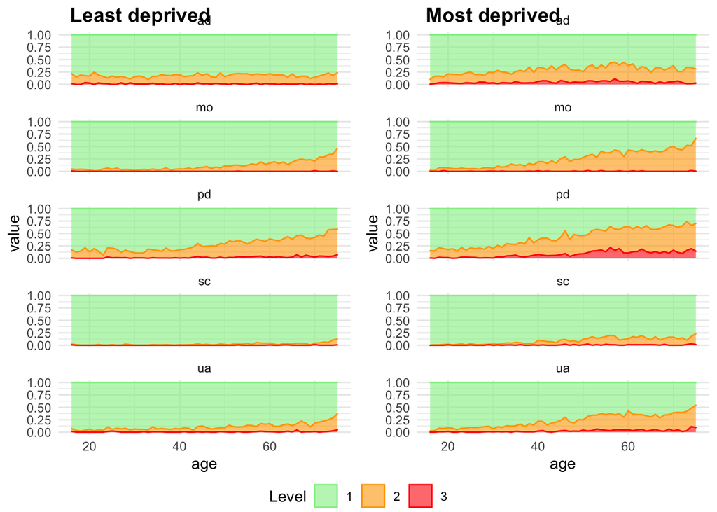

```r
    dimnames_s = names(dim_agg_o_1)[4:8]
    for(dim in dimnames_s){
    temp = dim_agg_o[,c(1,2,3,grep(dim,names(dim_agg_o)))]
    temp.rowsum = rowSums(temp[,4:6])
    temp[,4:6] = temp[4:6]/temp.rowsum
    # temp[,4:6] = t(apply(temp[,4:6],1,cumsum))
    # temp$dimension = dim
    dim_agg_o[,c(1,2,3,grep(dim,names(dim_agg_o)))] = temp
    }

    # reshape df from wide to long format
    dim_agg_o_long = reshape2::melt(dim_agg_o,id.vars = c("imd","sex","age"),variable.name = "level")
    dim_agg_o_long$dimension = substr(dim_agg_o_long$level,1,2)
    dim_agg_o_long$level = substr(dim_agg_o_long$level,4,4)
    dim_agg_o_long = dim_agg_o_long[dim_agg_o_long$dimension!="di",]

    # Plot
    # eq5d dim levels by age - imd 1 + female - pooled
    pd1 = ggplot(dim_agg_o_long[dim_agg_o_long$sex=="Female" & dim_agg_o_long$imd == "Least deprived",],
                aes(x=age, y=value,fill=as.factor(level),
                    col=as.factor(level))) +
    geom_area(position = 'stack',alpha=0.6)   +
    facet_wrap(~dimension,nrow = 5)  +
    scale_color_manual(values = c("lightgreen","orange","red"),
                        labels = c(1,2,3),name="Level")  +
    scale_fill_manual(values = c("lightgreen","orange","red"),
                        labels = c(1,2,3),name="Level")  +
    theme_minimal()+
    theme(legend.position = "bottom")
    pd_legend = get_legend(pd1)
    # eq5d dim levels by age - imd 5 + female - pooled
    pd2 =ggplot(dim_agg_o_long[dim_agg_o_long$sex=="Female" & dim_agg_o_long$imd == "Most deprived",],
                aes(x=age, y=value,fill=as.factor(level),
                    col=as.factor(level))) +
    geom_area(position = 'stack',alpha=0.6)   +
    scale_color_manual(values = c("lightgreen","orange","red"),
                        labels = c(1,2,3),name="Level")  +
    scale_fill_manual(values = c("lightgreen","orange","red"),
                        labels = c(1,2,3),name="Level")  +
    facet_wrap(~dimension,nrow = 5)  +
    theme_minimal()+
    theme(legend.position = "bottom")

    plot_grid(
    plot_grid(labels = c("Least deprived","Most deprived"),
                pd1+theme(legend.position = "none"),
                pd2+theme(legend.position = "none"),
                ncol=2),
    pd_legend,
    ncol = 1,rel_heights = c(15,1))
```

# ADD-ONS

## Year effects on HRQoL

**Overall mean eq5d index by age in different years (smoothened trend lines)**

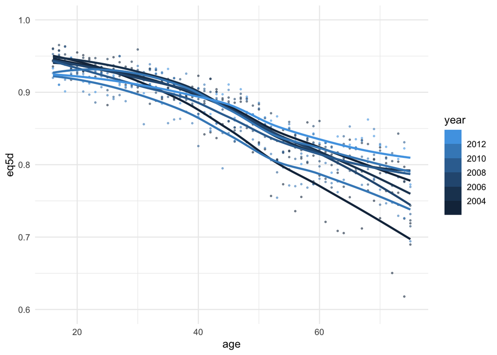

```r
    # ADD-ON: YEAR EFFECT?
    df_years = aggregate(eq5d ~ year+age,hse_combined,mean)

    # mean eq5d over lifetime by year
    ggplot(df_years) +
        geom_point(aes(x=age,y= eq5d,col=year),size=0.5,alpha=0.5) +
        geom_smooth(aes(x=age,y= eq5d,col = year, group=as.factor(year)),se = F,alpha=1,size=1) +
        scale_color_steps()+
        theme_minimal() +
        coord_cartesian(ylim=c(0.6,1))
```

```r
# # 2014 and 2004 had lower values
  #  summary(lm(eq5d ~year+age,df_years))
  #  summary(lm(eq5d ~as.factor(year)*age,df_years))
```

## year effect on inequality?

**Ratio of the mean eq5d indices of the least and most deprived quantile by age in different years (smoothened trend lines)**

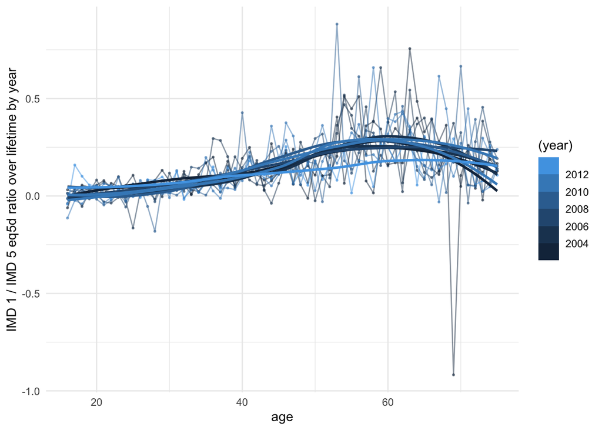

```r
    # IMD 1 / IMD 5 RATIO over lifetime by year
    df_years_imd1 = aggregate(eq5d ~ year+age+imd,hse_combined[as.numeric(hse_combined$imd) == 1,],mean)
    names(df_years_imd1)[4] = "eq5d_1"
    df_years_imd5 = aggregate(eq5d ~ year+age+imd,hse_combined[as.numeric(hse_combined$imd) == 5,],mean)
    names(df_years_imd5)[4] = "eq5d_5"
    df_years_r = merge(df_years_imd1,df_years_imd5,by=c("year","age"))
    df_years_r$ineq_ratio = df_years_r$eq5d_1/df_years_r$eq5d_5-1

    ggplot(df_years_r,aes(x=age,y=ineq_ratio,col=(year),group=as.factor(year))) +
        geom_point(size=0.5,alpha=0.5) +
        geom_line(size=0.5,alpha=0.5) +
        geom_smooth(se=F) +
        scale_color_steps()+
        ylab("IMD 1 / IMD 5 eq5d ratio over lifetime by year") +
        theme_minimal()
```